# Figure 7. Cluster-adjusted comparison of ocular outcomes among groups 0-5

Reproducible analysis

2026-08-18

## Overview

This document reproduces the statistical analyses and four-panel plot for Figure 7. The analysis includes experimental groups 0-5 only. Each row represents one eye, and `mouse_id` identifies the mouse-level cluster used to account for inter-eye correlation.

The four outcomes are ICGA polyp presence, ICGA polyp count, maximal vortex vein diameter at T0, and choroidal thickness at T1. The overall P values for these four outcomes are Bonferroni-adjusted across outcomes. Within each outcome, all 15 pairwise comparisons among the six groups are Bonferroni-adjusted as one post hoc family.

## Load and validate the source data

```r
d <- read.csv("fig7_data.csv", stringsAsFactors = FALSE, check.names = FALSE)
d <- d[d$group %in% 0:5, ]
d$group <- factor(d$group, levels = 0:5)
d$mouse_id <- factor(d$mouse_id)
d <- d[order(d$mouse_id, d$eye_id), ]

expected_eyes <- c(`0` = 28, `1` = 23, `2` = 14, `3` = 27, `4` = 13, `5` = 15)
observed_eyes <- table(d$group)
stopifnot(identical(as.integer(observed_eyes), as.integer(expected_eyes)))
stopifnot(!anyDuplicated(d$eye_id))
stopifnot(all(d$polyp_present %in% c(0, 1)))
stopifnot(all(d$polyp_count >= 0))

data.frame(
  group = levels(d$group),
  eyes = as.integer(table(d$group)),
  mice = as.integer(tapply(d$mouse_id, d$group, function(x) length(unique(x))))
)
```

```
##   group eyes mice
## 1     0   28   18
## 2     1   23   15
## 3     2   14   14
## 4     3   27   15
## 5     4   13   13
## 6     5   15   15
```

## Descriptive statistics

```r
descriptive <- do.call(rbind, lapply(levels(d$group), function(g) {
  x <- d[d$group == g, ]
  data.frame(
    group = g,
    eyes = nrow(x),
    mice = length(unique(x$mouse_id)),
    eyes_with_polyps = sum(x$polyp_present),
    eyes_with_polyps_percent = 100 * mean(x$polyp_present),
    polyp_count_mean = mean(x$polyp_count),
    polyp_count_sd = sd(x$polyp_count),
    vein_t0_mean_um = mean(x$vein_t0_um),
    vein_t0_sd_um = sd(x$vein_t0_um),
    choroid_t1_mean_um = mean(x$choroid_t1_um),
    choroid_t1_sd_um = sd(x$choroid_t1_um)
  )
}))

write.csv(descriptive, "fig7_descriptive_statistics.csv", row.names = FALSE)
knitr::kable(descriptive, digits = 3)
```

| group | eyes | mice | eyes_with_polyps | eyes_with_polyps_percent | polyp_count_mean | polyp_count_sd | vein_t0_mean_um | vein_t0_sd_um | choroid_t1_mean_um | choroid_t1_sd_um |
| --- | --- | --- | --- | --- | --- | --- | --- | --- | --- | --- |
| 0 | 28 | 18 | 0 | 0.000 | 0.000 | 0.000 | 885.786 | 73.794 | 38.018 | 3.304 |
| 1 | 23 | 15 | 11 | 47.826 | 5.957 | 7.510 | 1536.617 | 119.139 | 58.200 | 3.562 |
| 2 | 14 | 14 | 1 | 7.143 | 1.071 | 4.009 | 1143.429 | 164.928 | 48.250 | 4.180 |
| 3 | 27 | 15 | 0 | 0.000 | 0.000 | 0.000 | 1115.070 | 186.842 | 51.752 | 3.861 |
| 4 | 13 | 13 | 0 | 0.000 | 0.000 | 0.000 | 1240.515 | 183.039 | 44.331 | 5.377 |
| 5 | 15 | 15 | 0 | 0.000 | 0.000 | 0.000 | 918.593 | 156.162 | 39.207 | 3.332 |

## Statistical methods

ICGA polyp presence was analyzed using a second-order Rao-Scott chi-square test based on a survey design clustered by mouse. Polyp count, maximal vortex vein diameter, and choroidal thickness were analyzed using Gaussian identity-link generalized estimating equations with an exchangeable working correlation structure and a mouse-clustered robust sandwich covariance matrix.

The omnibus tests evaluate whether any group differs from the others. Their four raw P values are Bonferroni-adjusted across outcomes. Post hoc analyses include all 15 group pairs within each outcome, with Bonferroni adjustment performed separately for each outcome.

### GEE implementation

```r
fit_gaussian_gee <- function(data, outcome, tolerance = 1e-10, max_iterations = 100) {
  y <- data[[outcome]]
  X <- model.matrix(~ group, data = data)
  cluster_rows <- split(seq_len(nrow(data)), data$mouse_id)
  n <- length(y)
  p <- ncol(X)

  beta <- as.numeric(solve(crossprod(X), crossprod(X, y)))
  alpha <- 0
  converged <- FALSE

  for (iteration in seq_len(max_iterations)) {
    residual <- y - as.numeric(X %*% beta)
    phi <- sum(residual^2) / (n - p)
    pair_products <- unlist(lapply(cluster_rows, function(idx) {
      if (length(idx) < 2) return(numeric(0))
      combn(residual[idx], 2, FUN = prod)
    }))
    alpha_new <- if (length(pair_products)) mean(pair_products) / phi else 0
    alpha_new <- max(-0.95, min(0.95, alpha_new))

    bread <- matrix(0, p, p)
    rhs <- numeric(p)
    for (idx in cluster_rows) {
      Xi <- X[idx, , drop = FALSE]
      yi <- y[idx]
      ni <- length(idx)
      Ri <- matrix(alpha_new, ni, ni)
      diag(Ri) <- 1
      Ri_inv <- solve(Ri)
      bread <- bread + crossprod(Xi, Ri_inv %*% Xi)
      rhs <- rhs + as.numeric(crossprod(Xi, Ri_inv %*% yi))
    }

    beta_new <- as.numeric(solve(bread, rhs))
    if (max(abs(beta_new - beta)) < tolerance && abs(alpha_new - alpha) < tolerance) {
      beta <- beta_new
      alpha <- alpha_new
      converged <- TRUE
      break
    }
    beta <- beta_new
    alpha <- alpha_new
  }
  names(beta) <- colnames(X)

  bread <- matrix(0, p, p)
  meat <- matrix(0, p, p)
  for (idx in cluster_rows) {
    Xi <- X[idx, , drop = FALSE]
    residual_i <- y[idx] - as.numeric(Xi %*% beta)
    ni <- length(idx)
    Ri <- matrix(alpha, ni, ni)
    diag(Ri) <- 1
    Ri_inv <- solve(Ri)
    bread <- bread + crossprod(Xi, Ri_inv %*% Xi)
    score_i <- crossprod(Xi, Ri_inv %*% residual_i)
    meat <- meat + score_i %*% t(score_i)
  }

  bread_inv <- solve(bread)
  robust_vcov <- bread_inv %*% meat %*% bread_inv
  dimnames(robust_vcov) <- list(names(beta), names(beta))

  group_coefficients <- match(paste0("group", 1:5), names(beta))
  b_group <- beta[group_coefficients]
  v_group <- robust_vcov[group_coefficients, group_coefficients, drop = FALSE]
  effective_df <- qr(v_group, tol = 1e-9)$rank
  omnibus_statistic <- as.numeric(
    t(b_group) %*% MASS::ginv(v_group, tol = 1e-9) %*% b_group
  )

  omnibus <- data.frame(
    outcome = outcome,
    method = "Gaussian identity-link GEE; robust Wald test",
    statistic = omnibus_statistic,
    df1 = effective_df,
    df2 = NA_real_,
    p_raw = pchisq(omnibus_statistic, df = effective_df, lower.tail = FALSE)
  )

  group_pairs <- combn(0:5, 2)
  contrast_matrix <- matrix(0, nrow = ncol(group_pairs), ncol = ncol(X))
  comparison_names <- character(ncol(group_pairs))

  for (k in seq_len(ncol(group_pairs))) {
    first_group <- group_pairs[1, k]
    second_group <- group_pairs[2, k]
    first_mean <- numeric(ncol(X))
    second_mean <- numeric(ncol(X))
    first_mean[1] <- 1
    second_mean[1] <- 1
    if (first_group > 0) first_mean[first_group + 1] <- 1
    if (second_group > 0) second_mean[second_group + 1] <- 1
    contrast_matrix[k, ] <- first_mean - second_mean
    comparison_names[k] <- paste(first_group, second_group, sep = "-")
  }

  estimates <- as.numeric(contrast_matrix %*% beta)
  standard_errors <- sqrt(pmax(
    0,
    diag(contrast_matrix %*% robust_vcov %*% t(contrast_matrix))
  ))
  z_statistics <- ifelse(
    standard_errors < 1e-12 & abs(estimates) < 1e-12,
    0,
    estimates / standard_errors
  )
  p_values <- ifelse(
    standard_errors < 1e-12 & abs(estimates) < 1e-12,
    1,
    2 * pnorm(abs(z_statistics), lower.tail = FALSE)
  )

  pairwise <- data.frame(
    outcome = outcome,
    method = "GEE robust Wald contrast",
    comparison = comparison_names,
    estimate_first_minus_second = estimates,
    robust_standard_error = standard_errors,
    statistic = z_statistics,
    p_raw = p_values,
    p_bonferroni_15 = pmin(1, 15 * p_values)
  )

  diagnostics <- data.frame(
    outcome = outcome,
    clusters = length(cluster_rows),
    exchangeable_correlation = alpha,
    converged = converged,
    iterations = iteration,
    robust_covariance_rank = effective_df
  )

  list(omnibus = omnibus, pairwise = pairwise, diagnostics = diagnostics)
}
```

### Rao-Scott tests for ICGA polyp presence

```r
survey_design <- svydesign(ids = ~ mouse_id, weights = ~ 1, data = d)
binary_overall_test <- svychisq(
  ~ group + polyp_present,
  design = survey_design,
  statistic = "F"
)

binary_overall <- data.frame(
  outcome = "polyp_present",
  method = "Second-order Rao-Scott chi-square test",
  statistic = unname(binary_overall_test$statistic),
  df1 = unname(binary_overall_test$parameter[1]),
  df2 = unname(binary_overall_test$parameter[2]),
  p_raw = binary_overall_test$p.value
)

group_pairs <- combn(0:5, 2)
binary_pairwise <- vector("list", ncol(group_pairs))

for (k in seq_len(ncol(group_pairs))) {
  first_group <- group_pairs[1, k]
  second_group <- group_pairs[2, k]
  pair_data <- droplevels(d[as.integer(as.character(d$group)) %in% c(first_group, second_group), ])
  first_rate <- mean(pair_data$polyp_present[as.integer(as.character(pair_data$group)) == first_group])
  second_rate <- mean(pair_data$polyp_present[as.integer(as.character(pair_data$group)) == second_group])

  if (length(unique(pair_data$polyp_present)) < 2) {
    test_statistic <- 0
    p_value <- 1
  } else {
    pair_design <- svydesign(ids = ~ mouse_id, weights = ~ 1, data = pair_data)
    pair_test <- svychisq(~ group + polyp_present, design = pair_design, statistic = "F")
    test_statistic <- unname(pair_test$statistic)
    p_value <- pair_test$p.value
  }

  binary_pairwise[[k]] <- data.frame(
    outcome = "polyp_present",
    method = "Pairwise second-order Rao-Scott chi-square test",
    comparison = paste(first_group, second_group, sep = "-"),
    estimate_first_minus_second = 100 * (first_rate - second_rate),
    robust_standard_error = NA_real_,
    statistic = test_statistic,
    p_raw = p_value
  )
}

binary_pairwise <- do.call(rbind, binary_pairwise)
binary_pairwise$p_bonferroni_15 <- pmin(1, 15 * binary_pairwise$p_raw)
```

### GEE analyses and multiplicity adjustment

```r
gee_fits <- lapply(
  c("polyp_count", "vein_t0_um", "choroid_t1_um"),
  function(outcome) fit_gaussian_gee(d, outcome)
)

overall_results <- rbind(
  binary_overall,
  do.call(rbind, lapply(gee_fits, `[[`, "omnibus"))
)
overall_results$p_bonferroni_4_outcomes <- pmin(1, 4 * overall_results$p_raw)
overall_results$significant_after_bonferroni <- overall_results$p_bonferroni_4_outcomes < 0.05

pairwise_results <- rbind(
  binary_pairwise,
  do.call(rbind, lapply(gee_fits, `[[`, "pairwise"))
)
pairwise_results$significant_after_bonferroni <- pairwise_results$p_bonferroni_15 < 0.05

diagnostics <- do.call(rbind, lapply(gee_fits, `[[`, "diagnostics"))

write.csv(overall_results, "fig7_overall_tests.csv", row.names = FALSE)
write.csv(pairwise_results, "fig7_pairwise_tests.csv", row.names = FALSE)
write.csv(diagnostics, "fig7_gee_diagnostics.csv", row.names = FALSE)
writeLines(capture.output(sessionInfo()), "fig7_session_info.txt")
```

## Overall group comparisons

The Bonferroni-adjusted P value in the final column controls the family-wise error rate across the four outcomes.

```r
knitr::kable(overall_results, digits = 6)
```

|  | outcome | method | statistic | df1 | df2 | p_raw | p_bonferroni_4_outcomes | significant_after_bonferroni |
| --- | --- | --- | --- | --- | --- | --- | --- | --- |
| X-squared | polyp_present | Second-order Rao-Scott chi-square test | 7.895127 | 3.843216 | 295.9276 | 0.000007 | 0.000026 | TRUE |
| 1 | polyp_count | Gaussian identity-link GEE; robust Wald test | 13.699059 | 3.000000 | NA | 0.003345 | 0.013379 | TRUE |
| 2 | vein_t0_um | Gaussian identity-link GEE; robust Wald test | 671.048234 | 5.000000 | NA | 0.000000 | 0.000000 | TRUE |
| 3 | choroid_t1_um | Gaussian identity-link GEE; robust Wald test | 586.831925 | 5.000000 | NA | 0.000000 | 0.000000 | TRUE |

## Post hoc pairwise comparisons

For each outcome, the Bonferroni-adjusted P value controls the family-wise error rate across all 15 group pairs.

```r
knitr::kable(pairwise_results, digits = 6)
```

|  | outcome | method | comparison | estimate_first_minus_second | robust_standard_error | statistic | p_raw | p_bonferroni_15 | significant_after_bonferroni |
| --- | --- | --- | --- | --- | --- | --- | --- | --- | --- |
| X-squared | polyp_present | Pairwise second-order Rao-Scott chi-square test | 0-1 | -47.826087 | NA | 17.420696 | 0.000214 | 0.003216 | TRUE |
| X-squared1 | polyp_present | Pairwise second-order Rao-Scott chi-square test | 0-2 | -7.142857 | NA | 2.022891 | 0.164929 | 1.000000 | FALSE |
| 1 | polyp_present | Pairwise second-order Rao-Scott chi-square test | 0-3 | 0.000000 | NA | 0.000000 | 1.000000 | 1.000000 | FALSE |
| 11 | polyp_present | Pairwise second-order Rao-Scott chi-square test | 0-4 | 0.000000 | NA | 0.000000 | 1.000000 | 1.000000 | FALSE |
| 12 | polyp_present | Pairwise second-order Rao-Scott chi-square test | 0-5 | 0.000000 | NA | 0.000000 | 1.000000 | 1.000000 | FALSE |
| X-squared2 | polyp_present | Pairwise second-order Rao-Scott chi-square test | 1-2 | 40.683230 | NA | 6.345233 | 0.017759 | 0.266383 | FALSE |
| X-squared3 | polyp_present | Pairwise second-order Rao-Scott chi-square test | 1-3 | 47.826087 | NA | 16.701213 | 0.000316 | 0.004740 | TRUE |
| X-squared4 | polyp_present | Pairwise second-order Rao-Scott chi-square test | 1-4 | 47.826087 | NA | 9.322539 | 0.005040 | 0.075601 | FALSE |
| X-squared5 | polyp_present | Pairwise second-order Rao-Scott chi-square test | 1-5 | 47.826087 | NA | 10.557461 | 0.002925 | 0.043881 | TRUE |
| X-squared6 | polyp_present | Pairwise second-order Rao-Scott chi-square test | 2-3 | 7.142857 | NA | 1.944495 | 0.174148 | 1.000000 | FALSE |
| X-squared7 | polyp_present | Pairwise second-order Rao-Scott chi-square test | 2-4 | 7.142857 | NA | 0.959366 | 0.336373 | 1.000000 | FALSE |
| X-squared8 | polyp_present | Pairwise second-order Rao-Scott chi-square test | 2-5 | 7.142857 | NA | 1.104740 | 0.302215 | 1.000000 | FALSE |
| 13 | polyp_present | Pairwise second-order Rao-Scott chi-square test | 3-4 | 0.000000 | NA | 0.000000 | 1.000000 | 1.000000 | FALSE |
| 14 | polyp_present | Pairwise second-order Rao-Scott chi-square test | 3-5 | 0.000000 | NA | 0.000000 | 1.000000 | 1.000000 | FALSE |
| 15 | polyp_present | Pairwise second-order Rao-Scott chi-square test | 4-5 | 0.000000 | NA | 0.000000 | 1.000000 | 1.000000 | FALSE |
| 110 | polyp_count | GEE robust Wald contrast | 0-1 | -5.989996 | 1.686010 | -3.552765 | 0.000381 | 0.005718 | TRUE |
| 2 | polyp_count | GEE robust Wald contrast | 0-2 | -1.071429 | 1.032454 | -1.037749 | 0.299387 | 1.000000 | FALSE |
| 3 | polyp_count | GEE robust Wald contrast | 0-3 | 0.000000 | 0.000000 | 0.000000 | 1.000000 | 1.000000 | FALSE |
| 4 | polyp_count | GEE robust Wald contrast | 0-4 | 0.000000 | 0.000000 | 0.000000 | 1.000000 | 1.000000 | FALSE |
| 5 | polyp_count | GEE robust Wald contrast | 0-5 | 0.000000 | 0.000000 | 0.000000 | 1.000000 | 1.000000 | FALSE |
| 6 | polyp_count | GEE robust Wald contrast | 1-2 | 4.918567 | 1.977016 | 2.487875 | 0.012851 | 0.192764 | FALSE |
| 7 | polyp_count | GEE robust Wald contrast | 1-3 | 5.989996 | 1.686010 | 3.552765 | 0.000381 | 0.005718 | TRUE |
| 8 | polyp_count | GEE robust Wald contrast | 1-4 | 5.989996 | 1.686010 | 3.552765 | 0.000381 | 0.005718 | TRUE |
| 9 | polyp_count | GEE robust Wald contrast | 1-5 | 5.989996 | 1.686010 | 3.552765 | 0.000381 | 0.005718 | TRUE |
| 10 | polyp_count | GEE robust Wald contrast | 2-3 | 1.071429 | 1.032454 | 1.037749 | 0.299387 | 1.000000 | FALSE |
| 111 | polyp_count | GEE robust Wald contrast | 2-4 | 1.071429 | 1.032454 | 1.037749 | 0.299387 | 1.000000 | FALSE |
| 121 | polyp_count | GEE robust Wald contrast | 2-5 | 1.071429 | 1.032454 | 1.037749 | 0.299387 | 1.000000 | FALSE |
| 131 | polyp_count | GEE robust Wald contrast | 3-4 | 0.000000 | 0.000000 | 0.000000 | 1.000000 | 1.000000 | FALSE |
| 141 | polyp_count | GEE robust Wald contrast | 3-5 | 0.000000 | 0.000000 | 0.000000 | 1.000000 | 1.000000 | FALSE |
| 151 | polyp_count | GEE robust Wald contrast | 4-5 | 0.000000 | 0.000000 | 0.000000 | 1.000000 | 1.000000 | FALSE |
| 16 | vein_t0_um | GEE robust Wald contrast | 0-1 | -650.971322 | 25.726740 | -25.303297 | 0.000000 | 0.000000 | TRUE |
| 17 | vein_t0_um | GEE robust Wald contrast | 0-2 | -257.550618 | 44.876464 | -5.739102 | 0.000000 | 0.000000 | TRUE |
| 18 | vein_t0_um | GEE robust Wald contrast | 0-3 | -229.116215 | 40.225157 | -5.695844 | 0.000000 | 0.000000 | TRUE |
| 19 | vein_t0_um | GEE robust Wald contrast | 0-4 | -354.290879 | 50.879783 | -6.963294 | 0.000000 | 0.000000 | TRUE |
| 20 | vein_t0_um | GEE robust Wald contrast | 0-5 | -32.675315 | 41.559116 | -0.786237 | 0.431729 | 1.000000 | FALSE |
| 21 | vein_t0_um | GEE robust Wald contrast | 1-2 | 393.420704 | 47.500262 | 8.282495 | 0.000000 | 0.000000 | TRUE |
| 22 | vein_t0_um | GEE robust Wald contrast | 1-3 | 421.855108 | 43.132831 | 9.780372 | 0.000000 | 0.000000 | TRUE |
| 23 | vein_t0_um | GEE robust Wald contrast | 1-4 | 296.680443 | 53.208365 | 5.575823 | 0.000000 | 0.000000 | TRUE |
| 24 | vein_t0_um | GEE robust Wald contrast | 1-5 | 618.296007 | 44.379476 | 13.932026 | 0.000000 | 0.000000 | TRUE |
| 25 | vein_t0_um | GEE robust Wald contrast | 2-3 | 28.434403 | 56.678682 | 0.501677 | 0.615895 | 1.000000 | FALSE |
| 26 | vein_t0_um | GEE robust Wald contrast | 2-4 | -96.740261 | 64.677369 | -1.495736 | 0.134722 | 1.000000 | FALSE |
| 27 | vein_t0_um | GEE robust Wald contrast | 2-5 | 224.875302 | 57.633062 | 3.901845 | 0.000095 | 0.001432 | TRUE |
| 28 | vein_t0_um | GEE robust Wald contrast | 3-4 | -125.174665 | 61.541273 | -2.033995 | 0.041952 | 0.629281 | FALSE |
| 29 | vein_t0_um | GEE robust Wald contrast | 3-5 | 196.440899 | 54.090073 | 3.631737 | 0.000282 | 0.004223 | TRUE |
| 30 | vein_t0_um | GEE robust Wald contrast | 4-5 | 321.615564 | 62.534388 | 5.143019 | 0.000000 | 0.000004 | TRUE |
| 31 | choroid_t1_um | GEE robust Wald contrast | 0-1 | -20.010435 | 0.995196 | -20.107021 | 0.000000 | 0.000000 | TRUE |
| 32 | choroid_t1_um | GEE robust Wald contrast | 0-2 | -10.193633 | 1.288190 | -7.913146 | 0.000000 | 0.000000 | TRUE |
| 33 | choroid_t1_um | GEE robust Wald contrast | 0-3 | -13.756355 | 1.069775 | -12.859116 | 0.000000 | 0.000000 | TRUE |
| 34 | choroid_t1_um | GEE robust Wald contrast | 0-4 | -6.184903 | 1.563598 | -3.955560 | 0.000076 | 0.001145 | TRUE |
| 35 | choroid_t1_um | GEE robust Wald contrast | 0-5 | -0.889453 | 1.108518 | -0.802380 | 0.422333 | 1.000000 | FALSE |
| 36 | choroid_t1_um | GEE robust Wald contrast | 1-2 | 9.816802 | 1.284092 | 7.644939 | 0.000000 | 0.000000 | TRUE |
| 37 | choroid_t1_um | GEE robust Wald contrast | 1-3 | 6.254080 | 1.064836 | 5.873279 | 0.000000 | 0.000000 | TRUE |
| 38 | choroid_t1_um | GEE robust Wald contrast | 1-4 | 13.825532 | 1.560223 | 8.861253 | 0.000000 | 0.000000 | TRUE |
| 39 | choroid_t1_um | GEE robust Wald contrast | 1-5 | 19.120982 | 1.103753 | 17.323599 | 0.000000 | 0.000000 | TRUE |
| 40 | choroid_t1_um | GEE robust Wald contrast | 2-3 | -3.562722 | 1.342719 | -2.653364 | 0.007969 | 0.119541 | FALSE |
| 41 | choroid_t1_um | GEE robust Wald contrast | 2-4 | 4.008730 | 1.761622 | 2.275590 | 0.022871 | 0.343058 | FALSE |
| 42 | choroid_t1_um | GEE robust Wald contrast | 2-5 | 9.304180 | 1.373786 | 6.772655 | 0.000000 | 0.000000 | TRUE |
| 43 | choroid_t1_um | GEE robust Wald contrast | 3-4 | 7.571452 | 1.608819 | 4.706218 | 0.000003 | 0.000038 | TRUE |
| 44 | choroid_t1_um | GEE robust Wald contrast | 3-5 | 12.866902 | 1.171441 | 10.983827 | 0.000000 | 0.000000 | TRUE |
| 45 | choroid_t1_um | GEE robust Wald contrast | 4-5 | 5.295450 | 0.970209 | 5.458049 | 0.000000 | 0.000001 | TRUE |

## Figure 7 plot

The first panel shows the percentage of eyes with ICGA polypoidal lesions. The other three panels show boxplots with individual eye-level observations. Boxes represent the interquartile range, horizontal lines represent medians, and whiskers extend to 1.5 times the interquartile range. Significance letters reproduce the annotation scheme supplied with the figure reference. No numerical values or P values are added to the panels.

```r
roman_labels <- c("I", "II", "III", "IV", "V", "VI")
d$group_plot <- factor(d$group, levels = 0:5, labels = roman_labels)

polyp_summary <- aggregate(polyp_present ~ group_plot, data = d, FUN = mean)
polyp_summary$percent <- 100 * polyp_summary$polyp_present

polyp_letters <- data.frame(
  group_plot = factor(roman_labels, levels = roman_labels),
  label = c("b", "a", "ab", "b", "b", "b"),
  y = c(3.0, 51.5, 10.5, 3.0, 3.0, 3.0)
)
count_letters <- data.frame(
  group_plot = factor(roman_labels, levels = roman_labels),
  label = c("b", "a", "b", "b", "b", "b"),
  y = c(0.8, 22.8, 0.8, 0.8, 0.8, 0.8)
)
vein_letters <- data.frame(
  group_plot = factor(roman_labels, levels = roman_labels),
  label = c("c", "a", "b", "b", "b", "c"),
  y = c(1010, 1725, 1465, 1465, 1785, 1210)
)
choroid_letters <- data.frame(
  group_plot = factor(roman_labels, levels = roman_labels),
  label = c("d", "a", "bc", "b", "c", "d"),
  y = c(45.0, 65.0, 57.5, 63.0, 51.5, 46.0)
)

blue_fill <- "#9BC5F2"
blue_edge <- "#69A8EE"
pink_fill <- "#E8A1BC"
pink_edge <- "#DD6F96"

figure_theme <- theme_classic(base_size = 8, base_family = "Arial") +
  theme(
    text = element_text(family = "Arial", size = 8, color = "#000000"),
    axis.title = element_text(size = 8, color = "#000000"),
    axis.text = element_text(size = 8, color = "#000000"),
    axis.line = element_line(linewidth = 0.35, color = "#000000"),
    axis.ticks = element_line(linewidth = 0.35, color = "#000000"),
    panel.grid.major.y = element_line(linewidth = 0.25, linetype = "dashed", color = "#E8E8E8"),
    panel.grid.minor = element_blank(),
    legend.position = "none",
    plot.background = element_rect(fill = "white", color = NA),
    panel.background = element_rect(fill = "white", color = NA),
    plot.margin = margin(0, 0, 0, 0, unit = "pt")
  )

p1 <- ggplot(polyp_summary, aes(x = group_plot, y = percent)) +
  geom_col(width = 0.55, fill = blue_fill, color = blue_edge, linewidth = 0.4) +
  geom_text(data = polyp_letters, aes(x = group_plot, y = y, label = label),
            inherit.aes = FALSE, family = "Arial", size = 8 / ggplot2::.pt, color = "#000000") +
  scale_y_continuous(limits = c(0, 107), breaks = seq(0, 100, 20), expand = c(0, 0)) +
  labs(x = NULL, y = "Proportion of eyes\nshowing polyps (%)") +
  figure_theme

p2 <- ggplot(d, aes(x = group_plot, y = polyp_count)) +
  geom_boxplot(width = 0.5, outlier.shape = NA, fill = pink_fill, color = pink_edge, linewidth = 0.4) +
  geom_point(position = position_jitter(width = 0.14, height = 0, seed = 20260825),
             size = 0.8, alpha = 0.65, color = pink_edge) +
  geom_text(data = count_letters, aes(x = group_plot, y = y, label = label),
            inherit.aes = FALSE, family = "Arial", size = 8 / ggplot2::.pt, color = "#000000") +
  scale_y_continuous(limits = c(-1, 24), breaks = seq(0, 20, 5), expand = c(0, 0)) +
  labs(x = NULL, y = "Number of polyps") +
  figure_theme

p3 <- ggplot(d, aes(x = group_plot, y = vein_t0_um)) +
  geom_boxplot(width = 0.5, outlier.shape = NA, fill = pink_fill, color = pink_edge, linewidth = 0.4) +
  geom_point(position = position_jitter(width = 0.14, height = 0, seed = 20260825),
             size = 0.8, alpha = 0.65, color = pink_edge) +
  geom_text(data = vein_letters, aes(x = group_plot, y = y, label = label),
            inherit.aes = FALSE, family = "Arial", size = 8 / ggplot2::.pt, color = "#000000") +
  scale_y_continuous(limits = c(600, 1900), breaks = c(800, 1200, 1600),
                     labels = scales::label_comma(), expand = c(0, 0)) +
  labs(x = NULL, y = "Vortex vein diameter (µm)") +
  figure_theme

p4 <- ggplot(d, aes(x = group_plot, y = choroid_t1_um)) +
  geom_boxplot(width = 0.5, outlier.shape = NA, fill = blue_fill, color = blue_edge, linewidth = 0.4) +
  geom_point(position = position_jitter(width = 0.14, height = 0, seed = 20260825),
             size = 0.8, alpha = 0.65, color = blue_edge) +
  geom_text(data = choroid_letters, aes(x = group_plot, y = y, label = label),
            inherit.aes = FALSE, family = "Arial", size = 8 / ggplot2::.pt, color = "#000000") +
  scale_y_continuous(limits = c(30, 73.5), breaks = seq(30, 70, 10), expand = c(0, 0)) +
  labs(x = NULL, y = "Choroidal thickness (µm)") +
  figure_theme

combined_plot <- gridExtra::arrangeGrob(
  p1, p2, p3, p4,
  ncol = 4,
  padding = grid::unit(0, "pt")
)

page_plot <- gridExtra::arrangeGrob(
  grid::nullGrob(), combined_plot,
  ncol = 2,
  widths = grid::unit.c(grid::unit(0.68, "cm"), grid::unit(1, "null")),
  padding = grid::unit(0, "pt")
)

if (identical(Sys.info()[["sysname"]], "Darwin") && capabilities("aqua")) {
  quartzFonts(Arial = quartzFont(c("Arial", "Arial Bold", "Arial Italic", "Arial Bold Italic")))
  quartz(
    type = "pdf",
    file = "fig7.pdf",
    width = 21.59 / 2.54,
    height = (7.60 * 2 / 3) / 2.54,
    family = "Arial"
  )
} else {
  grDevices::cairo_pdf(
    filename = "fig7.pdf",
    width = 21.59 / 2.54,
    height = (7.60 * 2 / 3) / 2.54,
    family = "Arial"
  )
}
grid::grid.draw(page_plot)
dev.off()
```

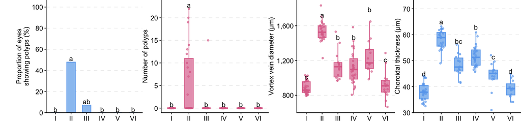

```r
if (isTRUE(getOption("knitr.in.progress"))) {
  grid::grid.draw(page_plot)
}
```